# QK Box 11.3

The rat pup dataset from Pinheiro and Bates (2000) was introduced in Chapter 10. The between-plots factor was drug treatment (fixed with three doses: control, low dose, high dose) and the plots were ten female rats, and their subsequent litters (level 2), assigned to each treatment. The pups from a litter produced by each female were sexed and weighed, so pups were the sub-plots (level 1) with sex (fixed: male vs females) as the within-plots factor and pup weight as the response variable. Litter size (number of pups) was recorded as a continuous covariate for each litter (level 2) as we might reasonably expect larger litters to have smaller pups on average. The design was unbalanced for both plots (only seven out of ten rats survived in the high dose group) and subplots (litter size ranged between two and 18 pups). Additionally, one litter (number 12) only had female pups so this litter was omitted from the analysis to avoid a missing cell.

This analysis uses a subset of the data - it’s here

### Preliminaries

First, load the required packages (afex, car, lattice, lme4, lmerTest, nlme, VCA, ez, emmeans, Rmisc, MuMIn)

Import ratpupno12 data file (ratpupno12.csv)

```r
ratpupno12 <- read.csv("../data/ratpupno12.csv")
ratpupno12
```

| weight | sex | litter | lsize | treatment | pup |
| --- | --- | --- | --- | --- | --- |
| 6.60 | Male | 1 | 12 | Control | 1 |
| 7.40 | Male | 1 | 12 | Control | 2 |
| 7.15 | Male | 1 | 12 | Control | 3 |
| 7.24 | Male | 1 | 12 | Control | 4 |
| 7.10 | Male | 1 | 12 | Control | 5 |
| 6.04 | Male | 1 | 12 | Control | 6 |
| 6.98 | Male | 1 | 12 | Control | 7 |
| 7.05 | Male | 1 | 12 | Control | 8 |
| 6.95 | Female | 1 | 12 | Control | 9 |
| 6.29 | Female | 1 | 12 | Control | 10 |

[output cut: 310 more lines]

Set contrasts from afex Make litter a factor

```r
set_sum_contrasts()
```

```
## setting contr.sum globally: options(contrasts=c('contr.sum', 'contr.poly'))
```

```r
ratpupno12$litter <- factor(ratpupno12$litter)
```

Check boxplots - some variance difference but not related to mean

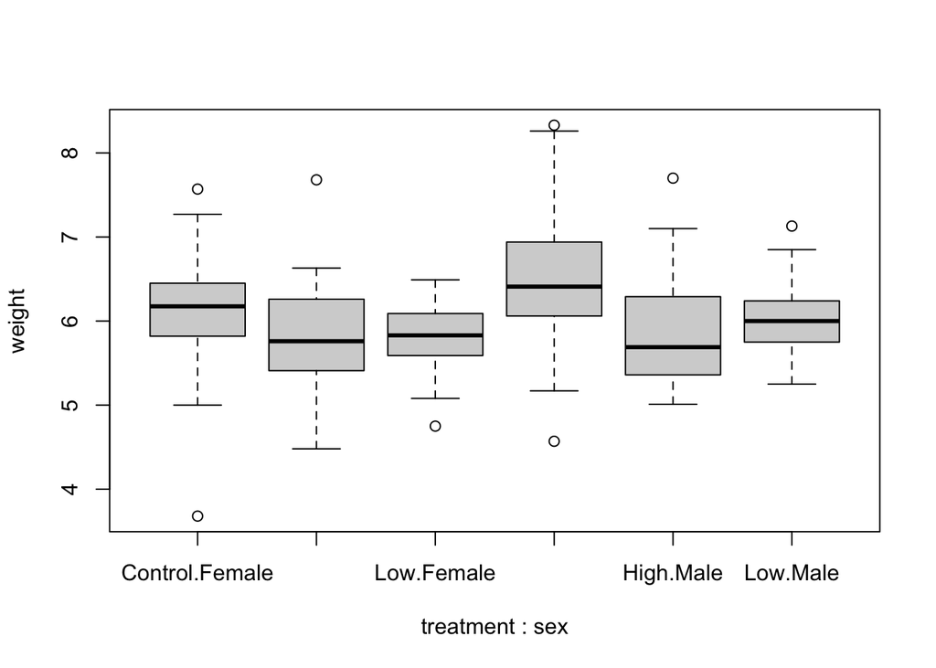

```r
boxplot(weight~treatment*sex, ratpupno12)
```

Not suited to OLS fit because of imbalance

## Without covariate

First, model using lmer without litter size as covariate - this model includes litter(treatment) x sex interaction

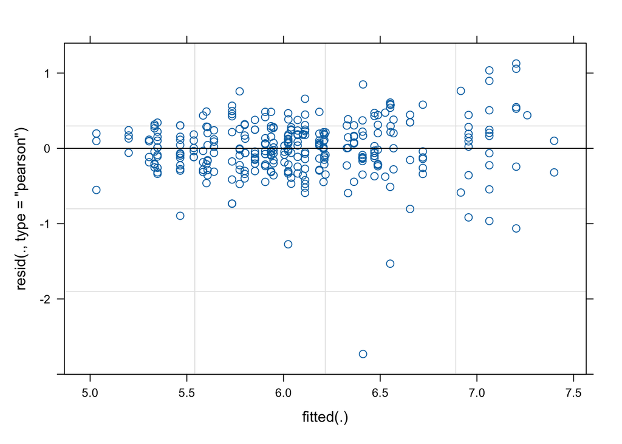

```r
ratpup.lmer1 <- lmer(weight~treatment+sex+treatment*sex+(1|litter)+(1|litter:sex), REML=TRUE, ratpupno12)
plot(ratpup.lmer1)
```

```r
summary(ratpup.lmer1, ddf="Kenward-Roger")
```

```
## Linear mixed model fit by REML. t-tests use Kenward-Roger's method [
## lmerModLmerTest]
## Formula: weight ~ treatment + sex + treatment * sex + (1 | litter) + (1 |
##     litter:sex)
##    Data: ratpupno12
##
## REML criterion at convergence: 420.9
##
## Scaled residuals:
##     Min      1Q  Median      3Q     Max
## -6.8869 -0.5151  0.0131  0.5374  2.8411
##
## Random effects:
##  Groups     Name        Variance Std.Dev.
##  litter:sex (Intercept) 0.01564  0.1251
##  litter     (Intercept) 0.25296  0.5030
##  Residual               0.15727  0.3966
## Number of obs: 320, groups:  litter:sex, 52; litter, 26
##
## Fixed effects:
##                 Estimate Std. Error       df t value Pr(>|t|)
## (Intercept)      6.13527    0.10450 23.14353  58.709  < 2e-16 ***
## treatment1       0.27970    0.14181 22.99973   1.972   0.0607 .
## treatment2      -0.06747    0.15614 23.56229  -0.432   0.6696
## sex1            -0.18000    0.03096 25.15990  -5.815  4.5e-06 ***
## treatment1:sex1 -0.03385    0.04090 22.29970  -0.828   0.4167
## treatment2:sex1  0.02127    0.04845 30.21454   0.439   0.6637
## ---
## Signif. codes:  0 '***' 0.001 '**' 0.01 '*' 0.05 '.' 0.1 ' ' 1
##
## Correlation of Fixed Effects:
##             (Intr) trtmn1 trtmn2 sex1   trt1:1
## treatment1  -0.117
## treatment2   0.155 -0.529
## sex1         0.002  0.017 -0.010
## trtmnt1:sx1  0.017  0.015 -0.005 -0.194
## trtmnt2:sx1 -0.010 -0.004 -0.005  0.287 -0.578
```

```r
anova (ratpup.lmer1, ddf="Kenward-Roger")
```

|  | Sum Sq | Mean Sq | NumDF | DenDF | F value | Pr(>F) |
| --- | --- | --- | --- | --- | --- | --- |
| treatment | 0.6938137 | 0.34690686 | 2 | 23.09072 | 2.2057280 | 1.328512e-01 |
| sex | 5.3172839 | 5.31728388 | 1 | 25.15990 | 33.8089030 | 4.501402e-06 |
| treatment:sex | 0.1080862 | 0.05404312 | 2 | 23.74943 | 0.3434351 | 7.127942e-01 |

Get variance components with profile CIs

```r
ratpup.ci <- confint.merMod(ratpup.lmer1,oldNames=FALSE)
```

```
## Computing profile confidence intervals ...
```

```r
ratpup.vc <- (ratpup.ci)^2
print(ratpup.vc)
```

```
##                                  2.5 %       97.5 %
## sd_(Intercept)|litter:sex 0.000000e+00  0.046258112
## sd_(Intercept)|litter     1.234467e-01  0.429932364
## sigma                     1.335858e-01  0.188435117
## (Intercept)               3.522724e+01 40.136473884
## treatment1                9.926651e-05  0.305713065
## treatment2                1.339955e-01  0.053504195
## sex1                      5.675929e-02  0.014566084
## treatment1:sex1           1.254337e-02  0.001852688
## treatment2:sex1           4.848962e-03  0.012933502
```

Now simplify model by testing if litter(treatment) x sex term should be retained

```r
ratpup.lmer1a <- lmer(weight~treatment+sex+treatment*sex+(1|litter)+(1|litter:sex), REML=FALSE, ratpupno12)
ratpup.lmer2 <- lmer(weight~treatment+sex+treatment*sex+(1|litter), REML=FALSE, ratpupno12)
anova(ratpup.lmer1a, ratpup.lmer2)
```

|  | npar | AIC | BIC | logLik | deviance | Chisq | Df | Pr(>Chisq) |
| --- | --- | --- | --- | --- | --- | --- | --- | --- |
| ratpup.lmer2 | 8 | 415.7166 | 445.8632 | -199.8583 | 399.7166 | NA | NA | NA |
| ratpup.lmer1a | 9 | 417.0888 | 451.0037 | -199.5444 | 399.0888 | 0.6277966 | 1 | 0.4281647 |

```r
AICc(ratpup.lmer1a, ratpup.lmer2)
```

|  | df | AICc |
| --- | --- | --- |
| ratpup.lmer1a | 9 | 417.6695 |
| ratpup.lmer2 | 8 | 416.1796 |

### Use simpler model

```r
ratpup.lmer2a <- lmer(weight~treatment+sex+treatment*sex+(1|litter), REML=TRUE, ratpupno12)
summary(ratpup.lmer2a, ddf="Kenward-Roger")
```

```
## Linear mixed model fit by REML. t-tests use Kenward-Roger's method [
## lmerModLmerTest]
## Formula: weight ~ treatment + sex + treatment * sex + (1 | litter)
##    Data: ratpupno12
##
## REML criterion at convergence: 422.5
##
## Scaled residuals:
##     Min      1Q  Median      3Q     Max
## -7.3671 -0.4894  0.0064  0.5477  3.1089
##
## Random effects:
##  Groups   Name        Variance Std.Dev.
##  litter   (Intercept) 0.2641   0.5139
##  Residual             0.1634   0.4042
## Number of obs: 320, groups:  litter, 26
##
## Fixed effects:
##                  Estimate Std. Error        df t value Pr(>|t|)
## (Intercept)       6.13428    0.10509  23.12458  58.373  < 2e-16 ***
## treatment1        0.28459    0.14266  23.01002   1.995    0.058 .
## treatment2       -0.06812    0.15696  23.52001  -0.434    0.668
## sex1             -0.17674    0.02555 295.61185  -6.917 2.86e-11 ***
## treatment1:sex1  -0.03098    0.03317 294.19956  -0.934    0.351
## treatment2:sex1   0.02024    0.04091 296.97605   0.495    0.621
## ---
## Signif. codes:  0 '***' 0.001 '**' 0.01 '*' 0.05 '.' 0.1 ' ' 1
##
## Correlation of Fixed Effects:
##             (Intr) trtmn1 trtmn2 sex1   trt1:1
## treatment1  -0.116
## treatment2   0.154 -0.529
## sex1         0.005  0.018 -0.010
## trtmnt1:sx1  0.019  0.019 -0.007 -0.242
## trtmnt2:sx1 -0.009 -0.006 -0.003  0.351 -0.600
```

```r
anova(ratpup.lmer2a, ddf="Kenward-Roger")
```

|  | Sum Sq | Mean Sq | NumDF | DenDF | F value | Pr(>F) |
| --- | --- | --- | --- | --- | --- | --- |
| treatment | 0.7381737 | 0.36908687 | 2 | 23.07551 | 2.2589621 | 1.270697e-01 |
| sex | 7.8167202 | 7.81672024 | 1 | 295.61185 | 47.8417302 | 2.861892e-11 |
| treatment:sex | 0.1436983 | 0.07184915 | 2 | 295.03227 | 0.4397478 | 6.446204e-01 |

Get var comps

```r
ratpup.ci <- confint.merMod(ratpup.lmer2,oldNames=FALSE)
```

```
## Computing profile confidence intervals ...
```

```r
ratpup.vc <- (ratpup.ci)^2
print(ratpup.vc)
```

```
##                              2.5 %       97.5 %
## sd_(Intercept)|litter 1.310156e-01  0.437332352
## sigma                 1.381952e-01  0.191155575
## (Intercept)           3.521029e+01 40.138977305
## treatment1            1.448129e-04  0.310379990
## treatment2            1.351348e-01  0.053876450
## sex1                  5.113174e-02  0.015893474
## treatment1:sex1       9.272754e-03  0.001119387
## treatment2:sex1       3.483295e-03  0.010190477
```

## Fit ratpup.lmer2 model including covariate with simple effect

```r
ratpup.lmer4 <- lmer(weight~treatment+sex+treatment*sex+lsize+(1|litter), REML=TRUE, ratpupno12)
summary(ratpup.lmer4, ddf="Kenward-Roger")
```

```
## Linear mixed model fit by REML. t-tests use Kenward-Roger's method [
## lmerModLmerTest]
## Formula: weight ~ treatment + sex + treatment * sex + lsize + (1 | litter)
##    Data: ratpupno12
##
## REML criterion at convergence: 406.3
##
## Scaled residuals:
##     Min      1Q  Median      3Q     Max
## -7.4805 -0.5008  0.0275  0.5704  3.0167
##
## Random effects:
##  Groups   Name        Variance Std.Dev.
##  litter   (Intercept) 0.1001   0.3164
##  Residual             0.1630   0.4037
## Number of obs: 320, groups:  litter, 26
##
## Fixed effects:
##                  Estimate Std. Error        df t value Pr(>|t|)
## (Intercept)       7.67662    0.27842  27.04136  27.572  < 2e-16 ***
## treatment1        0.42523    0.09489  22.62806   4.482 0.000175 ***
## treatment2       -0.42228    0.11751  23.18499  -3.594 0.001520 **
## sex1             -0.17434    0.02541 300.85249  -6.861 3.90e-11 ***
## lsize            -0.12722    0.02206  25.89312  -5.766 4.58e-06 ***
## treatment1:sex1  -0.03163    0.03303 298.05341  -0.958 0.339005
## treatment2:sex1   0.02164    0.04062 303.45006   0.533 0.594629
## ---
## Signif. codes:  0 '***' 0.001 '**' 0.01 '*' 0.05 '.' 0.1 ' ' 1
##
## Correlation of Fixed Effects:
##             (Intr) trtmn1 trtmn2 sex1   lsize  trt1:1
## treatment1   0.221
## treatment2  -0.451 -0.577
## sex1        -0.023  0.020  0.001
## lsize       -0.970 -0.257  0.502  0.026
## trtmnt1:sx1  0.025  0.034 -0.020 -0.237 -0.018
## trtmnt2:sx1 -0.025 -0.017  0.010  0.346  0.023 -0.599
```

```r
anova(ratpup.lmer4, type="3", ddf="Kenward-Roger")
```

|  | Sum Sq | Mean Sq | NumDF | DenDF | F value | Pr(>F) |
| --- | --- | --- | --- | --- | --- | --- |
| treatment | 3.5205323 | 1.76026615 | 2 | 22.20002 | 10.7987339 | 5.301920e-04 |
| sex | 7.6727756 | 7.67277556 | 1 | 300.85249 | 47.0719842 | 3.903194e-11 |
| lsize | 5.4189317 | 5.41893170 | 1 | 25.89312 | 33.2447972 | 4.582528e-06 |
| treatment:sex | 0.1499268 | 0.07496341 | 2 | 299.77802 | 0.4598942 | 6.317951e-01 |

## Fit ratpup.lmer2 model including covariate (match West analysis)

```r
ratpup.lmer3 <- lmer(weight~treatment+sex+treatment*sex+lsize+treatment*lsize+(1|litter), REML=TRUE, ratpupno12)
summary(ratpup.lmer3, ddf="Kenward-Roger")
```

```
## Linear mixed model fit by REML. t-tests use Kenward-Roger's method [
## lmerModLmerTest]
## Formula: weight ~ treatment + sex + treatment * sex + lsize + treatment *
##     lsize + (1 | litter)
##    Data: ratpupno12
##
## REML criterion at convergence: 411.8
##
## Scaled residuals:
##     Min      1Q  Median      3Q     Max
## -7.4770 -0.5069  0.0096  0.5761  3.0265
##
## Random effects:
##  Groups   Name        Variance Std.Dev.
##  litter   (Intercept) 0.08843  0.2974
##  Residual             0.16287  0.4036
## Number of obs: 320, groups:  litter, 26
##
## Fixed effects:
##                    Estimate Std. Error         df t value Pr(>|t|)
## (Intercept)        7.429896   0.323326  22.059200  22.980  < 2e-16 ***
## treatment1         0.595882   0.389028  23.029597   1.532 0.139215
## treatment2         0.405952   0.402879  24.376536   1.008 0.323532
## sex1              -0.174655   0.025395 301.020191  -6.878 3.52e-11 ***
## lsize             -0.115517   0.025105  22.152562  -4.601 0.000137 ***
## treatment1:sex1   -0.030903   0.033007 298.289775  -0.936 0.349909
## treatment2:sex1    0.018630   0.040602 303.337744   0.459 0.646664
## treatment1:lsize  -0.005981   0.029544  22.655861  -0.202 0.841387
## treatment2:lsize  -0.072522   0.034670  24.334329  -2.092 0.047065 *
## ---
## Signif. codes:  0 '***' 0.001 '**' 0.01 '*' 0.05 '.' 0.1 ' ' 1
##
## Correlation of Fixed Effects:
##             (Intr) trtmn1 trtmn2 sex1   lsize  trt1:1 trt2:1 trtm1:
## treatment1  -0.460
## treatment2  -0.360  0.001
## sex1        -0.026  0.029 -0.023
## lsize       -0.969  0.474  0.237  0.033
## trtmnt1:sx1  0.027 -0.011  0.013 -0.237 -0.025
## trtmnt2:sx1 -0.018  0.011 -0.041  0.346  0.023 -0.599
## trtmnt1:lsz  0.484 -0.966  0.071 -0.027 -0.523  0.022 -0.020
## trtmnt2:lsz  0.214  0.063 -0.956  0.027 -0.069 -0.021  0.047 -0.179
```

```r
anova(ratpup.lmer3, type="3", ddf="Kenward-Roger")
```

|  | Sum Sq | Mean Sq | NumDF | DenDF | F value | Pr(>F) |
| --- | --- | --- | --- | --- | --- | --- |
| treatment | 0.5475839 | 0.27379193 | 2 | 23.61368 | 1.6806607 | 2.077737e-01 |
| sex | 7.7037984 | 7.70379839 | 1 | 301.02019 | 47.3013270 | 3.524626e-11 |
| lsize | 3.4484108 | 3.44841078 | 1 | 22.15256 | 21.1732444 | 1.367110e-04 |
| treatment:sex | 0.1454204 | 0.07271021 | 2 | 299.88893 | 0.4464392 | 6.403272e-01 |
| treatment:lsize | 0.7689496 | 0.38447480 | 2 | 22.90675 | 2.3602326 | 1.169492e-01 |

Contrast control to other 2 groups

```r
ratpup3.emm <- emmeans(ratpup.lmer3, ~treatment)
```

```
## NOTE: Results may be misleading due to involvement in interactions
```

```r
ratpup3.con <- contrast(ratpup3.emm, "trt.vs.ctrl", ref="Control")
summary(ratpup3.con, adjust="none")
```

|  | contrast | estimate | SE | df | t.ratio | p.value |
| --- | --- | --- | --- | --- | --- | --- |
| 1 | High - Control | -1.0815829 | 0.2252919 | 20.92006 | -4.800807 | 9.699399e-05 |
| 2 | Low - Control | -0.4656418 | 0.1483916 | 19.68880 | -3.137926 | 5.249933e-03 |

Get var comps

```r
ratpup.ci <- confint.merMod(ratpup.lmer3,oldNames=FALSE)
```

```
## Computing profile confidence intervals ...
```

```r
ratpup.vc <- (ratpup.ci)^2
print(ratpup.vc)
```

```
##                              2.5 %       97.5 %
## sd_(Intercept)|litter  0.035086693 1.308154e-01
## sigma                  0.137587610 1.900248e-01
## (Intercept)           46.899112019 6.419454e+01
## treatment1             0.010371330 1.690570e+00
## treatment2             0.103954079 1.278899e+00
## sex1                   0.049471899 1.516133e-02
## lsize                  0.025826883 4.948339e-03
## treatment1:sex1        0.009221154 1.067045e-03
## treatment2:sex1        0.003524194 9.702075e-03
## treatment1:lsize       0.003531796 2.208381e-03
## treatment2:lsize       0.018197201 9.723359e-05
```